# Case Study BellaBeat

Jesse Hilario

2022-07-29

[figure not shown]

## Scenario

Bellabeat is a high-tech manufacturer of health-focused products for women. Bellabeat is a successful small company, but they have the potential to become a larger player in the global smart device market. Urška Sršen, cofounder and Chief Creative Officer of Bellabeat, believes that analyzing smart device fitness data could help unlock new growth opportunities for the company.

## Ask

You have been asked to focus on one of Bellabeat’s products and analyze smart device data to gain insight into how consumers are using their smart devices. The insights you discover will then help guide marketing strategy for the company. You will present your analysis to the Bellabeat executive team along with your high-level recommendations for Bellabeat’s marketing strategy

#### Business Task

Analyze non-Bellabeat smart device usage data in order to gain insight into how the Leaf tracker, Bellabeat’s classic wellness tracker, might be used by consumers. Our insights can drive business decisions by adapting marketing strategy according to the trends found in order to target consumers who use non-Bellabeat smart devices and to increase engagement of current users.

#### Guiding Questions

1. What are some trends in smart device usage?
2. How could these trends apply to Bellabeat customers?
3. How could these trends help influence Bellabeat marketing strategy?

## Prepare

#### Loading Packages

```r
library(tidyverse)
library(janitor)
library(lubridate)
library(skimr)
library(GGally)
library(Hmisc)
library(RColorBrewer)
library(patchwork)
```

#### About the dataset

The product of focus will be Leaf, Bellabeat’s classic wellness tracker that can be worn as a bracelet, necklace, or clip.

[figure not shown]

The Leaf tracker connects to the Bellabeat app to track activity, sleep, and stress. We will use FitBit Data gathered from [FitBit Fitness Tracker Data](https://www.kaggle.com/datasets/arashnic/fitbit) (CC0: Public Domain, dataset made available through Mobius). This dataset was generated by respondents to a distributed survey via Amazon Mechanical Turk between 03.12.2016-05.12.2016.

This Kaggle data set contains personal fitness tracker from thirty fitbit users. Thirty eligible Fitbit users consented to the submission of personal tracker data, including minute-level output for physical activity, heart rate, and sleep monitoring. We will apply trends found with this dataset to Leaf marketing strategy.

#### Data storage, organization, and verification

Each dataset was stored as a Microsoft Excel CSV file. Almost all of the data could be classified as long; participants were repeated for every time that was recorded, allowing each participant to have multiple rows. Participants were anonymized with unique ID numbers.

We decided to use the following tables:

- **Daily Activity** 33 participants for 31 days tracking daily steps, distance, minutes, steps, and calories
- **Hourly Calories** 33 participants for 31 days tracking hourly calories burned
- **Hourly Intensities** 33 participants for 31 days tracking hourly total and average intensity
- **Daily Sleep** 24 participants for 31 days tracking daily minutes asleep and in bed
- **Hourly Steps** 33 participants for 31 days tracking hourly step totals

#### Importing dataset

```r
daily_activity <- read_csv("Fitabase Data 4.12.16-5.12.16/dailyActivity_merged.csv")
day_sleep <- read_csv("sleepDay_merged.csv")
hour_calories <- read_csv("Fitabase Data 4.12.16-5.12.16/hourlyCalories_merged.csv")
hour_intensities <- read_csv("Fitabase Data 4.12.16-5.12.16/hourlyIntensities_merged.csv")
hour_steps <- read_csv("Fitabase Data 4.12.16-5.12.16/hourlySteps_merged.csv")
```

#### Data integrity and limitations

Although certain datasets provided by the Fitbit Data were desirable for analysis, they were excluded as their validity was questionable. For instance, the WeightLogInfo dataset only included 8 participants; most only had one or two responses, making tracking progress impossible.

We can progress with caution to process our data.

## Process

#### Checking datasets

First we took a look at the datasets and verified the number of distinct participants.

```r
glimpse(daily_activity)
```

```
## Rows: 940
## Columns: 15
## $ Id                       <dbl> 1503960366, 1503960366, 1503960366, 150396036…
## $ ActivityDate             <chr> "4/12/2016", "4/13/2016", "4/14/2016", "4/15/…
## $ TotalSteps               <dbl> 13162, 10735, 10460, 9762, 12669, 9705, 13019…
## $ TotalDistance            <dbl> 8.50, 6.97, 6.74, 6.28, 8.16, 6.48, 8.59, 9.8…
## $ TrackerDistance          <dbl> 8.50, 6.97, 6.74, 6.28, 8.16, 6.48, 8.59, 9.8…
## $ LoggedActivitiesDistance <dbl> 0, 0, 0, 0, 0, 0, 0, 0, 0, 0, 0, 0, 0, 0, 0, …
## $ VeryActiveDistance       <dbl> 1.88, 1.57, 2.44, 2.14, 2.71, 3.19, 3.25, 3.5…
## $ ModeratelyActiveDistance <dbl> 0.55, 0.69, 0.40, 1.26, 0.41, 0.78, 0.64, 1.3…
## $ LightActiveDistance      <dbl> 6.06, 4.71, 3.91, 2.83, 5.04, 2.51, 4.71, 5.0…
## $ SedentaryActiveDistance  <dbl> 0, 0, 0, 0, 0, 0, 0, 0, 0, 0, 0, 0, 0, 0, 0, …
## $ VeryActiveMinutes        <dbl> 25, 21, 30, 29, 36, 38, 42, 50, 28, 19, 66, 4…
## $ FairlyActiveMinutes      <dbl> 13, 19, 11, 34, 10, 20, 16, 31, 12, 8, 27, 21…
## $ LightlyActiveMinutes     <dbl> 328, 217, 181, 209, 221, 164, 233, 264, 205, …
## $ SedentaryMinutes         <dbl> 728, 776, 1218, 726, 773, 539, 1149, 775, 818…
## $ Calories                 <dbl> 1985, 1797, 1776, 1745, 1863, 1728, 1921, 203…
```

```r
n_distinct(daily_activity$Id)
```

```
## [1] 33
```

```r
glimpse(day_sleep)
```

```
## Rows: 413
## Columns: 5
## $ Id                 <dbl> 1503960366, 1503960366, 1503960366, 1503960366, 150…
## $ SleepDay           <chr> "4/12/2016 12:00:00 AM", "4/13/2016 12:00:00 AM", "…
## $ TotalSleepRecords  <dbl> 1, 2, 1, 2, 1, 1, 1, 1, 1, 1, 1, 1, 1, 1, 1, 1, 1, …
## $ TotalMinutesAsleep <dbl> 327, 384, 412, 340, 700, 304, 360, 325, 361, 430, 2…
## $ TotalTimeInBed     <dbl> 346, 407, 442, 367, 712, 320, 377, 364, 384, 449, 3…
```

```r
n_distinct(day_sleep$Id)
```

```
## [1] 24
```

```r
glimpse(hour_calories)
```

```
## Rows: 22,099
## Columns: 3
## $ Id           <dbl> 1503960366, 1503960366, 1503960366, 1503960366, 150396036…
## $ ActivityHour <chr> "4/12/2016 12:00:00 AM", "4/12/2016 1:00:00 AM", "4/12/20…
## $ Calories     <dbl> 81, 61, 59, 47, 48, 48, 48, 47, 68, 141, 99, 76, 73, 66, …
```

```r
n_distinct(hour_calories$Id)
```

```
## [1] 33
```

```r
glimpse(hour_intensities$Id)
```

```
##  num [1:22099] 1.5e+09 1.5e+09 1.5e+09 1.5e+09 1.5e+09 ...
```

```r
n_distinct(hour_intensities$Id)
```

```
## [1] 33
```

```r
glimpse(hour_steps$Id)
```

```
##  num [1:22099] 1.5e+09 1.5e+09 1.5e+09 1.5e+09 1.5e+09 ...
```

```r
n_distinct(hour_steps$Id)
```

```
## [1] 33
```

#### Cleaning data

We used the clean_names() function to make the column names more uniform and the colnames() function to check the changes.

```r
daily_activity <- daily_activity %>%
  clean_names() %>%
  rename(date = activity_date)
colnames(daily_activity)
```

```
##  [1] "id"                         "date"
##  [3] "total_steps"                "total_distance"
##  [5] "tracker_distance"           "logged_activities_distance"
##  [7] "very_active_distance"       "moderately_active_distance"
##  [9] "light_active_distance"      "sedentary_active_distance"
## [11] "very_active_minutes"        "fairly_active_minutes"
## [13] "lightly_active_minutes"     "sedentary_minutes"
## [15] "calories"
```

```r
day_sleep <- day_sleep %>%
  clean_names() %>%
  rename(date = sleep_day)
colnames(day_sleep)
```

```
## [1] "id"                   "date"                 "total_sleep_records"
## [4] "total_minutes_asleep" "total_time_in_bed"
```

```r
hour_calories <- clean_names(hour_calories)
colnames(hour_calories)
```

```
## [1] "id"            "activity_hour" "calories"
```

```r
hour_intensities <- clean_names(hour_intensities)
colnames(hour_intensities)
```

```
## [1] "id"                "activity_hour"     "total_intensity"
## [4] "average_intensity"
```

```r
hour_steps <- clean_names(hour_steps)
colnames(hour_steps)
```

```
## [1] "id"            "activity_hour" "step_total"
```

We also cleaned the data formatting for id and date to better suit our analysis. We turned id into a string since each id represented individual people and not numerical integers.

```r
daily_activity <- daily_activity %>%
  mutate(activity_date = mdy(daily_activity$date),
         id = as.character(id))

day_sleep <- day_sleep %>%
  mutate(sleep_day = mdy_hms(day_sleep$date),
         id = as.character(id))

hour_calories <- hour_calories %>%
  mutate(activity_hour = mdy_hms(activity_hour),
         id = as.character((id)))

hour_intensities <- hour_intensities %>%
  mutate(activity_hour = mdy_hms(activity_hour),
         id = as.character(id))

hour_steps <- hour_steps %>%
  mutate(activity_hour = mdy_hms(activity_hour),
         id = as.character(id))
```

We found that day_sleep was the only dataframe with duplicate rows, so we removed them.

```r
sum(duplicated(daily_activity))
```

```
## [1] 0
```

```r
sum(duplicated(day_sleep))
```

```
## [1] 3
```

```r
sum(duplicated(hour_calories))
```

```
## [1] 0
```

```r
sum(duplicated(hour_intensities))
```

```
## [1] 0
```

```r
sum(duplicated(hour_steps))
```

```
## [1] 0
```

```r
count(day_sleep)  # number of rows in day_sleep
```

```
## # A tibble: 1 × 1
##       n
##   <int>
## 1   413
```

```r
day_sleep <- day_sleep %>%
  distinct() %>%
  drop_na()
count(day_sleep)
```

```
## # A tibble: 1 × 1
##       n
##   <int>
## 1   410
```

#### Merging the datasets

Finally, we merged the datasets. First, we verified the number of rows in each table. We noted that day_sleep has about half of the number of rows as daily_activity.

```r
# First we verified number of rows
nrow(daily_activity)
```

```
## [1] 940
```

```r
nrow(day_sleep)
```

```
## [1] 410
```

```r
nrow(hour_calories)
```

```
## [1] 22099
```

```r
nrow(hour_intensities)
```

```
## [1] 22099
```

```r
nrow(hour_steps)
```

```
## [1] 22099
```

Then, we merged the datasets by separating them between the daily and hourly. We used id as well as date or activity_hour as the primary keys.

```r
# Merging datasets that tracked daily
day_sleep <- day_sleep %>%
  separate(date, into=c('date','time'), sep=' ')
daily_activity_sleep <- merge(daily_activity, day_sleep, by=c("id","date"))
glimpse(daily_activity_sleep)
```

```
## Rows: 410
## Columns: 21
## $ id                         <chr> "1503960366", "1503960366", "1503960366", "…
## $ date                       <chr> "4/12/2016", "4/13/2016", "4/15/2016", "4/1…
## $ total_steps                <dbl> 13162, 10735, 9762, 12669, 9705, 15506, 105…
## $ total_distance             <dbl> 8.50, 6.97, 6.28, 8.16, 6.48, 9.88, 6.68, 6…
## $ tracker_distance           <dbl> 8.50, 6.97, 6.28, 8.16, 6.48, 9.88, 6.68, 6…
## $ logged_activities_distance <dbl> 0, 0, 0, 0, 0, 0, 0, 0, 0, 0, 0, 0, 0, 0, 0…
## $ very_active_distance       <dbl> 1.88, 1.57, 2.14, 2.71, 3.19, 3.53, 1.96, 1…
## $ moderately_active_distance <dbl> 0.55, 0.69, 1.26, 0.41, 0.78, 1.32, 0.48, 0…
## $ light_active_distance      <dbl> 6.06, 4.71, 2.83, 5.04, 2.51, 5.03, 4.24, 4…
## $ sedentary_active_distance  <dbl> 0, 0, 0, 0, 0, 0, 0, 0, 0, 0, 0, 0, 0, 0, 0…
## $ very_active_minutes        <dbl> 25, 21, 29, 36, 38, 50, 28, 19, 41, 39, 73,…
## $ fairly_active_minutes      <dbl> 13, 19, 34, 10, 20, 31, 12, 8, 21, 5, 14, 2…
## $ lightly_active_minutes     <dbl> 328, 217, 209, 221, 164, 264, 205, 211, 262…
## $ sedentary_minutes          <dbl> 728, 776, 726, 773, 539, 775, 818, 838, 732…
## $ calories                   <dbl> 1985, 1797, 1745, 1863, 1728, 2035, 1786, 1…
## $ activity_date              <date> 2016-04-12, 2016-04-13, 2016-04-15, 2016-0…
## $ time                       <chr> "12:00:00", "12:00:00", "12:00:00", "12:00:…
## $ total_sleep_records        <dbl> 1, 2, 1, 2, 1, 1, 1, 1, 1, 1, 1, 1, 1, 1, 1…
## $ total_minutes_asleep       <dbl> 327, 384, 412, 340, 700, 304, 360, 325, 361…
## $ total_time_in_bed          <dbl> 346, 407, 442, 367, 712, 320, 377, 364, 384…
## $ sleep_day                  <dttm> 2016-04-12, 2016-04-13, 2016-04-15, 2016-0…
```

```r
nrow(daily_activity_sleep)
```

```
## [1] 410
```

```r
# Merging datasets that tracked hourly
hourly_activity <- list(hour_calories, hour_intensities, hour_steps) %>%
  reduce(full_join, by=c("id","activity_hour"))
glimpse(hourly_activity)
```

```
## Rows: 22,099
## Columns: 6
## $ id                <chr> "1503960366", "1503960366", "1503960366", "150396036…
## $ activity_hour     <dttm> 2016-04-12 00:00:00, 2016-04-12 01:00:00, 2016-04-1…
## $ calories          <dbl> 81, 61, 59, 47, 48, 48, 48, 47, 68, 141, 99, 76, 73,…
## $ total_intensity   <dbl> 20, 8, 7, 0, 0, 0, 0, 0, 13, 30, 29, 12, 11, 6, 36, …
## $ average_intensity <dbl> 0.333333, 0.133333, 0.116667, 0.000000, 0.000000, 0.…
## $ step_total        <dbl> 373, 160, 151, 0, 0, 0, 0, 0, 250, 1864, 676, 360, 2…
```

```r
nrow(hourly_activity)
```

```
## [1] 22099
```

## Analyze and Share

#### Tracking the hours

First, we created a dataframe by adding a column in the merged hourly_activity dataset to keep track of the hours.

```r
hours <- hourly_activity %>%
  mutate(time = hour(activity_hour)) %>%
  group_by(time) %>%
  arrange(time)
```

Using this, we wanted to look at the correlations between hourly calories, average intensity, and step total.

```r
hours.rcorr <- hours %>%
  select(time,calories,average_intensity,step_total) %>%
  as.matrix() %>%
  rcorr()
hours.rcorr
```

```
##                   time calories average_intensity step_total
## time              1.00     0.18              0.21       0.18
## calories          0.18     1.00              0.90       0.81
## average_intensity 0.21     0.90              1.00       0.90
## step_total        0.18     0.81              0.90       1.00
##
## n= 22099
##
##
## P
##                   time calories average_intensity step_total
## time                    0        0                 0
## calories           0             0                 0
## average_intensity  0    0                          0
## step_total         0    0        0
```

We saw a strong correlation between calories, average intensity, and step total. We wanted to visualize this.

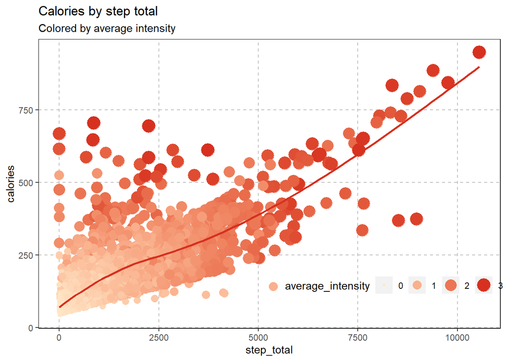

```r
# step_total by calories
calories_by_steps <- hours %>%
  ggplot() +
  geom_point(mapping = aes(x=step_total,y=calories,color=average_intensity,size=average_intensity)) +
  geom_smooth(mapping = aes(x=step_total,y=calories,color=average_intensity), alpha = 0, color = "#d7301f") +
  scale_color_gradient(low = "#fee8c8", high = "#d7301f") +
  guides(color = 'legend') +
  theme(plot.background = element_rect(fill = "transparent", color = "transparent"),
        panel.background = element_rect(fill = "transparent", colour = "gray"),
        panel.border = element_rect(fill = "transparent", colour = "black"),
        panel.grid.major = element_line(colour = "grey", linetype = "dashed"),
        legend.direction = "horizontal",
        legend.position = c(.77,.15),
        legend.background = element_blank()) +
  labs(title = "Calories by step total", subtitle = "Colored by average intensity")


intensity_by_steps <- hours %>%
  ggplot() +
  geom_point(mapping = aes(x=step_total,y=average_intensity,color=calories,size=calories)) +
  geom_smooth(mapping = aes(x=step_total,y=average_intensity,color=calories), alpha = 0,color = "blue") +
  scale_color_gradient(low = "#f7fcfd", high = "blue") +
  guides(color = 'legend') +
  theme(plot.background = element_rect(fill = "transparent", color = "transparent"),
        panel.background = element_rect(fill = "transparent", colour = "gray"),
        panel.border = element_rect(fill = "transparent", colour = "black"),
        panel.grid.major = element_line(colour = "grey", linetype = "dashed"),
        legend.direction = "horizontal",
        legend.position = c(.75,.30),
        legend.background = element_blank()) +
  labs(title = "Step total by average intensity", subtitle = "Colored by calories")

intensity_by_calories <- hours %>%
  ggplot() +
  geom_point(mapping = aes(x=calories,y=average_intensity,color=step_total,size=step_total)) +
  geom_smooth(mapping = aes(x=calories,y=average_intensity,color=step_total), alpha = 0, color = "#238b45") +
  scale_color_gradient(low = "#e5f5e0", high = "#006d2c") +
  guides(color = 'legend') +
  theme(plot.background = element_rect(fill = "transparent", color = "transparent"),
        panel.background = element_rect(fill = "transparent", colour = "grey"),
        panel.border = element_rect(fill = "transparent", colour = "black"),
        panel.grid.major = element_line(colour = "grey", linetype = "dashed"),
        legend.direction = "horizontal",
        legend.position = c(.7,.30),
        legend.background = element_blank()) +
  labs(title = "Calories by average intensity", subtitle = "Colored by step total")

calories_by_steps
```

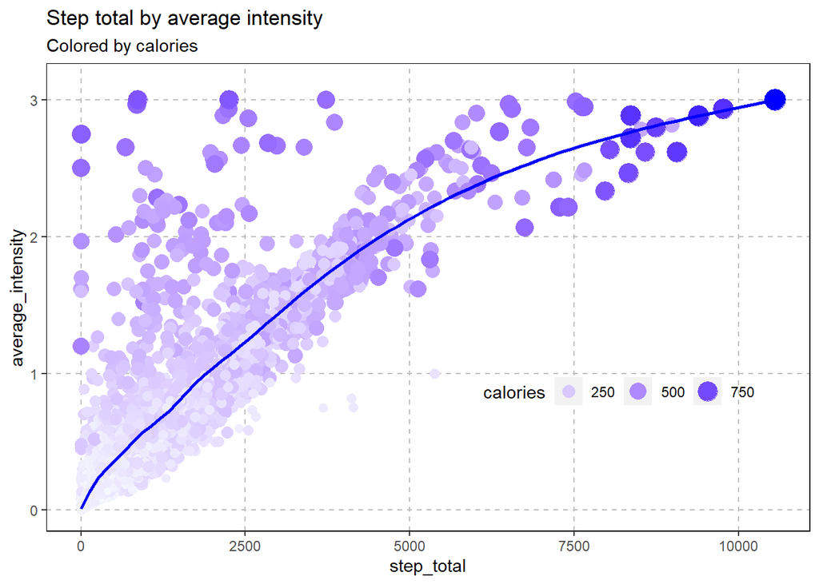

```r
intensity_by_steps
```

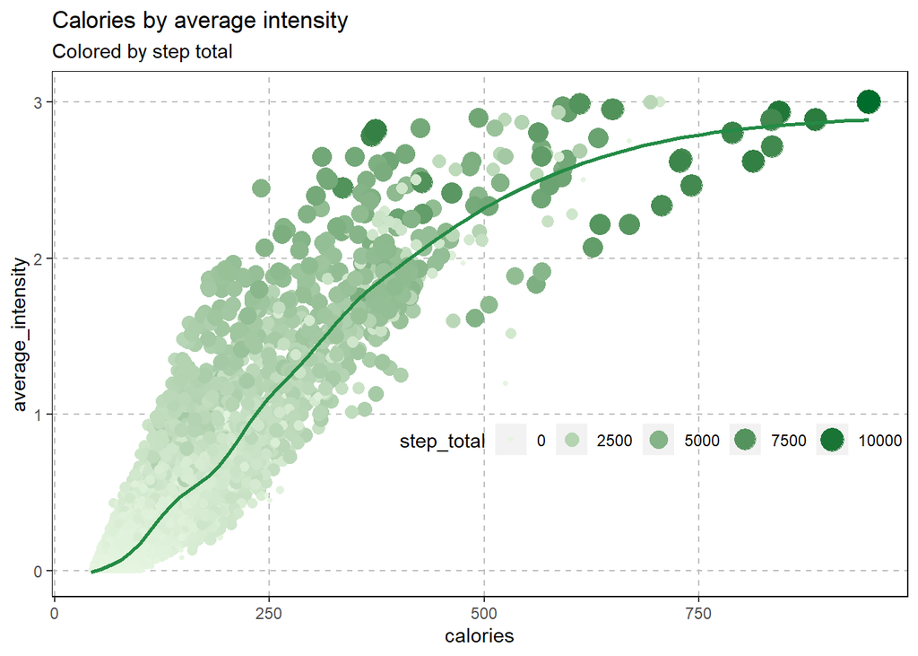

```r
intensity_by_calories
```

#### More hourly trends

We wanted to see if there were any trends throughout the day with each passing hour.

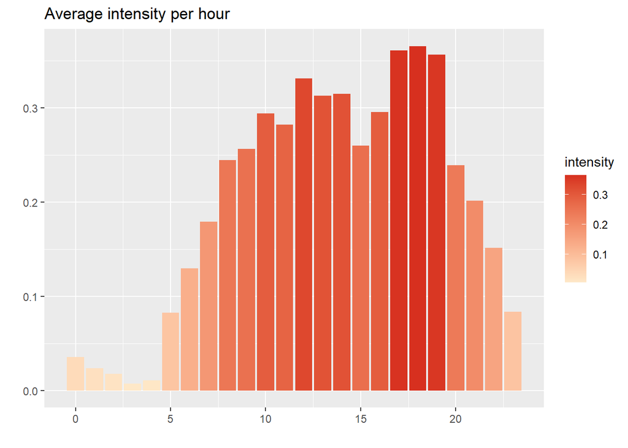

```r
hourly_intensities <- hours %>%
  group_by(time) %>%
  summarise(hourly_avg_intensity = mean(average_intensity))  %>%
  ggplot(aes(x=time, y=hourly_avg_intensity, fill=hourly_avg_intensity)) +
  geom_col() +
  labs(title = "Average intensity per hour", x="", y="") +
  scale_fill_gradient(low = "#fee8c8", high = "#d7301f", name = "intensity")

hourly_calories <- hours %>%
  group_by(time) %>%
  summarise(hourly_calories = mean(calories)) %>%
  ggplot(aes(x=time, y=hourly_calories, fill=hourly_calories)) +
  geom_col() +
  labs(title = "Calories burned per hour", x="", y="") +
  scale_fill_gradient2(low = "#f7fcfd", high = "blue", name = "calories")

hourly_steps <- hours %>%
  group_by(time) %>%
  summarise(hourly_avg_steps = mean(step_total)) %>%
  ggplot(aes(x=time, y=hourly_avg_steps, fill=hourly_avg_steps)) +
  geom_col() +
  labs(title = "Average steps per hour", x="", y="") +
  scale_fill_gradient2(low = "#c7e9c0", high = "#238b45", name = "steps")

hourly_intensities
```

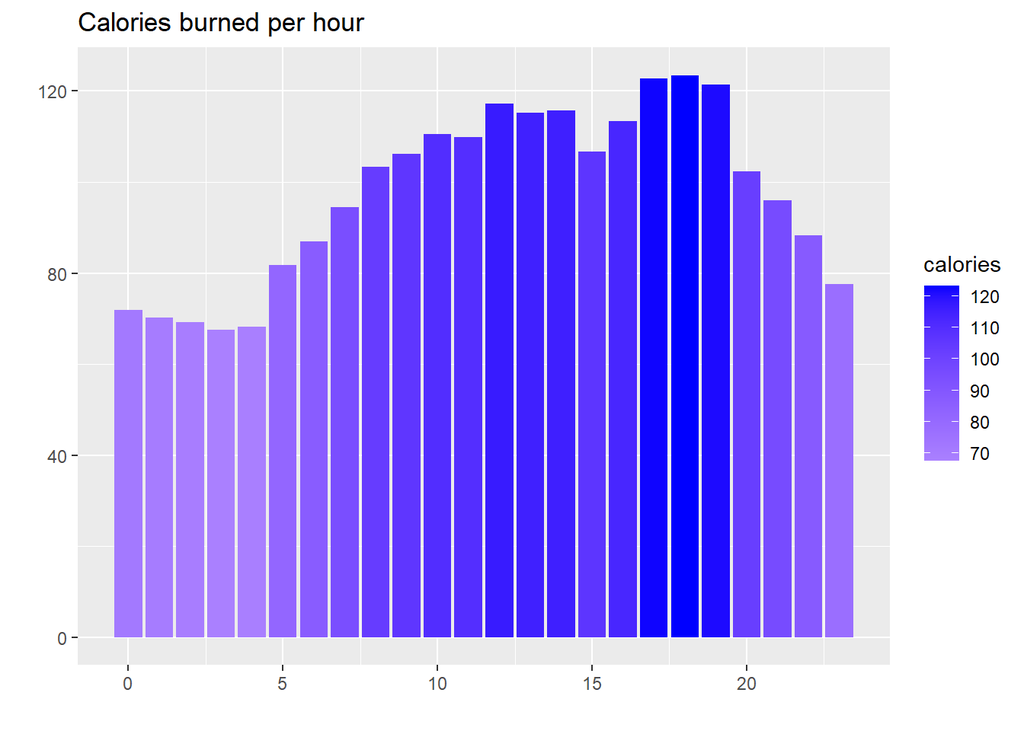

```r
hourly_calories
```

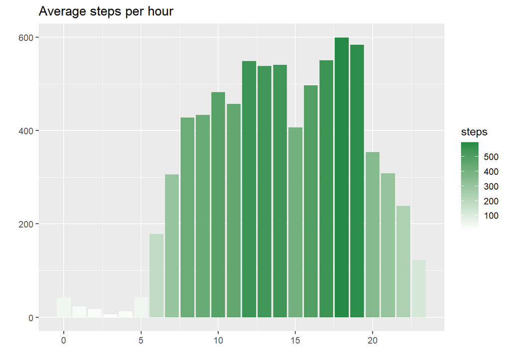

```r
hourly_steps
```

We were able to observe a few hourly trends:

- first peak between 12:00pm and 1:00pm
- greatest peak around the 18th hour, or 6:00pm
- activity picks up at about 5:00am and rapidly lowers at about 8:00pm
- activity was lowest between 12:00am and 4:00am

We thought it would be interesting to calculate each participant’s maximum hourly average intensity out of the entire day and represent it visually in order to see when people exerted themselves the most.

[output not shown]

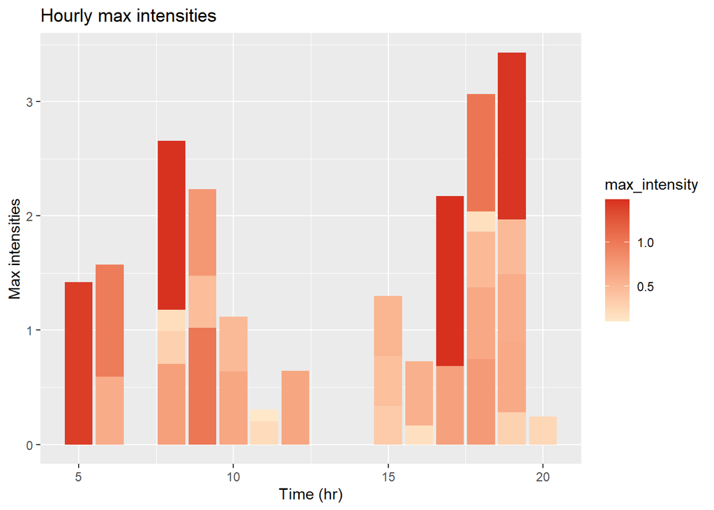

```r
hours %>%
  group_by(id, time) %>%
  summarise(hourly_avg_intensity = mean(average_intensity))  %>%
  group_by(id) %>%
  mutate(min_intensity = min(hourly_avg_intensity),
            max_intensity = max(hourly_avg_intensity)) %>%
  filter(hourly_avg_intensity == max_intensity) %>%
  ungroup() %>%
  ggplot(aes(x=time, y=max_intensity, fill=max_intensity)) +
  geom_col() +
  labs(title = "Hourly max intensities", x="Time (hr)", y="Max intensities") +
  scale_fill_gradient(low = "#fee8c8", high = "#d7301f")
```

Interestingly, when you graph the each participants’ maximum intensity in an hour out of all their measured hours, the trend has two peaks: the first is around 8:00am (unexpectedly) and the second around 7:00pm (which was expected). This, and the whole range of daily maximums, seems to suggest that users exercise with highest intensity at a wide variety of times

#### Tracking the days

Just as with the hourly merged dataset, we added a new column to keep track of the day of the month to make our analysis easier.

```r
daily_activity <- daily_activity %>%
  mutate(day = day(activity_date))

daily_activity_sleep <- daily_activity_sleep %>%
  mutate(day = day(activity_date))
```

We visualized this using a correlation heat map.

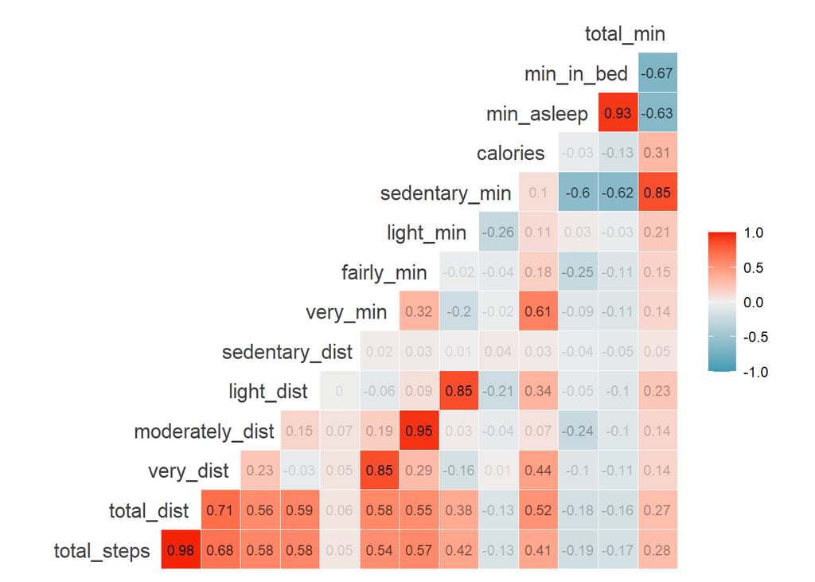

```r
daily_activity_sleep %>%
  group_by(id, activity_date) %>%
  mutate(total_minutes=mean(sum(sedentary_minutes,lightly_active_minutes,fairly_active_minutes,very_active_minutes))) %>%
  ungroup() %>%
  select(-id, -date, -tracker_distance, -logged_activities_distance, -activity_date, -time, -total_sleep_records,
         -sleep_day, -day)  %>%
  rename(sedentary_min=sedentary_minutes, light_min=lightly_active_minutes,            # renaming to reduce clutter
         fairly_min=fairly_active_minutes, very_min=very_active_minutes,
         sedentary_dist=sedentary_active_distance, light_dist=light_active_distance,
         moderately_dist=moderately_active_distance, very_dist=very_active_distance,
         min_asleep=total_minutes_asleep, min_in_bed=total_time_in_bed,
         total_min=total_minutes, total_dist = total_distance) %>%
  ggcorr(layout.exp = 2, label = T, label_size = 3, label_round = 2, label_alpha = T, hjust = .9, size = 4.5, color = "grey25")
```

#### Distances traveled by users on average

We wanted to see the distance each user traveled on an average day, as well as what proportion of that distance was spent in sedentary, light, moderate, or very active levels of intensity.

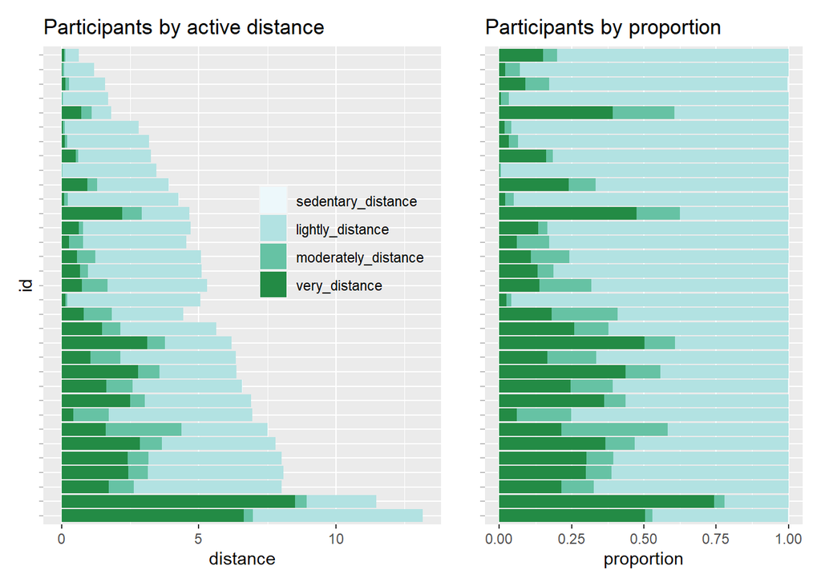

```r
active_distance <- daily_activity %>%
  group_by(id) %>%
  summarise(sedentary_distance=mean(sedentary_active_distance),
            lightly_distance=mean(light_active_distance),
            moderately_distance=mean(moderately_active_distance),,
            very_distance=mean(very_active_distance),
            total_distance=mean(total_distance)) %>%
  pivot_longer(names_to = "mean_distance",
               values_to = "distance",
               c(sedentary_distance,lightly_distance,moderately_distance,very_distance)) %>%
  mutate(mean_distance=factor(mean_distance,
                              levels = c("sedentary_distance", "lightly_distance", "moderately_distance","very_distance"),
                              ordered = TRUE)) %>%
  ungroup() %>%
  arrange(desc(total_distance)) %>%
  mutate(id = factor(id, levels = unique(id))) %>%
  ggplot() +
  geom_col(mapping = aes(x=id,y=distance,fill=mean_distance)) +
  coord_flip() +
  labs(title = "Participants by active distance") +
  scale_fill_discrete(type = c(very_distance = "#238b45",
                               moderately_distance="#66c2a4",
                               lightly_distance="#b2e2e2",
                               sedentary_distance="#edf8fb"),
                      aesthetics = "fill",
                      breaks = c("very_distance", "moderately_distance", "lightly_distance", "sedentary_distance")) +
  guides(fill=guide_legend(reverse = T)) +
  theme(axis.text.y=element_blank(),
        axis.ticks.y = element_line(colour = "grey"),
        legend.title = element_blank(),
        legend.position = c(.75,.6),
        legend.background = element_blank())

ggsave(filename = "Rplot.png")
## Proportion
active_distance_proportion <- daily_activity %>%
  group_by(id) %>%
  mutate(prop_sedentary = sedentary_active_distance / sum(sedentary_active_distance,light_active_distance,
                    moderately_active_distance,very_active_distance),
         prop_light = light_active_distance / sum(sedentary_active_distance,light_active_distance,
                    moderately_active_distance,very_active_distance),
         prop_moderately = moderately_active_distance / sum(sedentary_active_distance,light_active_distance,
                    moderately_active_distance,very_active_distance),
         prop_very = very_active_distance / sum(sedentary_active_distance,light_active_distance,
                    moderately_active_distance,very_active_distance),
            total_distance=mean(total_distance)) %>%
  pivot_longer(names_to = "prop_distance", values_to = "proportion", prop_sedentary:prop_very) %>%
  mutate(prop_distance=factor(prop_distance,
                              levels = c("prop_sedentary", "prop_light", "prop_moderately","prop_very"),
                              ordered = TRUE)) %>%
  ungroup() %>%
  arrange(desc(total_distance)) %>%
  mutate(id = factor(id, levels=unique(id))) %>%
  ggplot() +
  geom_col(mapping = aes(x=id,y=proportion,fill=prop_distance)) +
  coord_flip() +
  labs(title = "Participants by proportion", x="") +
  theme(axis.text.y=element_blank(),
        axis.ticks.y = element_line(colour = "grey"),
        legend.position = "none") +
  scale_fill_discrete(type = c(prop_very = "#238b45",
                               prop_moderately="#66c2a4",
                               prop_light="#b2e2e2",
                               prop_sedentary="#edf8fb"),
                      aesthetics = "fill",
                      breaks = c("prop_very", "prop_moderately", "prop_light", "prop_sedentary"))


active_distance + active_distance_proportion  +
  plot_layout(widths = c(5,4))
```

Observations:

- users come from a wide range of activity levels
- most distance is accounted for by light distance (e.g., light walking))

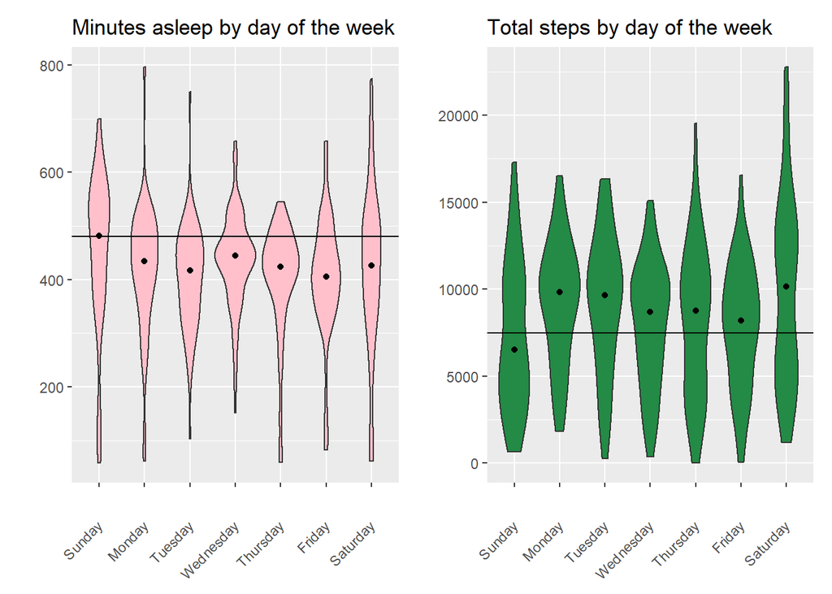

```r
# First, we created a data frame that includes the day of the week
days <- daily_activity_sleep %>%
  mutate(day_of_week = wday(activity_date),
         day_of_week = factor(x=day_of_week,
                              levels = c(1,2,3,4,5,6,7),
                              labels = c("Sunday","Monday","Tuesday","Wednesday","Thursday","Friday","Saturday"),
                              ordered = T))

ggplot(data=days) +
  geom_violin(scale = "area", mapping = aes(x=day_of_week,y=total_minutes_asleep), fill = "pink") +
  stat_summary(mapping = aes(x=day_of_week,y=total_minutes_asleep), fun = median, geom = 'point') +
  geom_hline(aes(yintercept=(8*60))) +
  labs(title = "Minutes asleep by day of the week", x= "", y = "") +
  theme(axis.text.x = element_text(angle = 45, vjust = .5, hjust = 1)) +
ggplot(data = days) +
  geom_violin(mapping = aes(x=day_of_week,y=total_steps), fill = "#238b45")  +
  stat_summary(mapping = aes(x=day_of_week,y=total_steps), fun = median, geom = 'point') +
  geom_hline(aes(yintercept=(7500))) +
  labs(title = "Total steps by day of the week", x= "", y = "") +
  theme(axis.text.x = element_text(angle = 45, vjust = .5, hjust = 1))
```

On average:

- users sleep the most on Sundays, which is the only day of the week they reach 8 hours of sleep
- users approach 7500 to 10,000 steps per day of the week

#### Minutes per week

According to the CDC’s recommendations on [Physical Activity for Different Groups](https://www.cdc.gov/physicalactivity/basics/age-chart.html), an adult should have “At least 150 minutes a week of moderate intensity activity such as brisk walking.” We took to find if the our Fitbit data saw users actually reached those goals, or if it could be something to target.

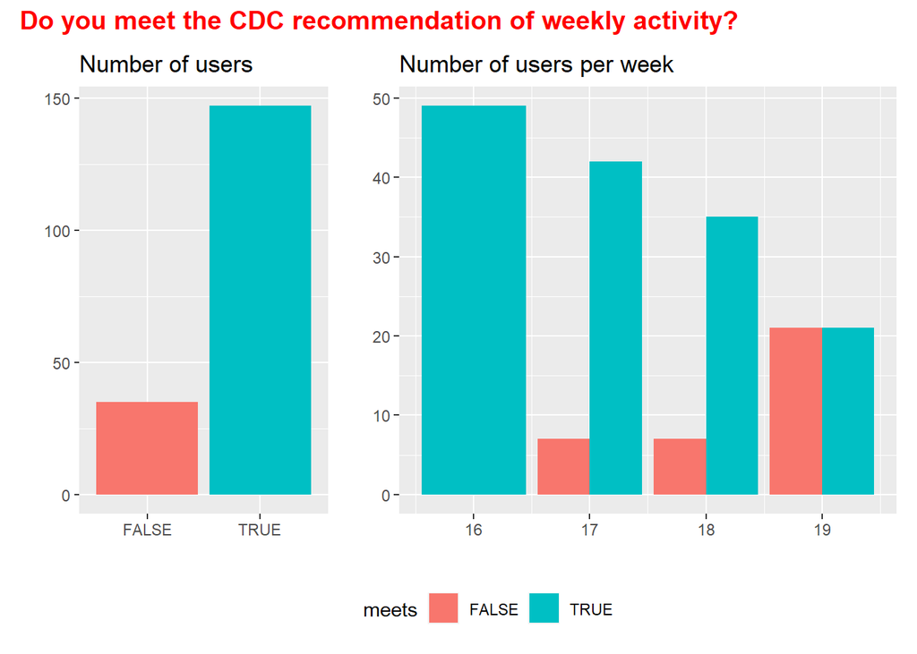

```r
weekly_meet_count <- days %>%
  group_by(id) %>%
  mutate(week = week(activity_date)) %>%
  group_by(id, week) %>%
  mutate(full_week = n() >= 7) %>%          # We did this only to include only complete weeks that had all 7 days
  filter(full_week == TRUE) %>%
  group_by(id, week) %>%
  mutate(active_min = sum(fairly_active_minutes, very_active_minutes),
            meets = active_min > 150) %>%
  ggplot() + geom_bar(mapping = aes(x=meets,fill=meets)) +
  labs(title = "Number of users", x = "", y = "")

weekly_meet <- days %>%
  group_by(id) %>%
  mutate(week = week(activity_date)) %>%
  group_by(id, week) %>%
  mutate(full_week = n() >= 7) %>%
  filter(full_week == TRUE) %>%
  group_by(id, week) %>%
  mutate(active_min = sum(fairly_active_minutes, very_active_minutes),
            meets = active_min > 150) %>%
  ggplot() +
  geom_bar(mapping = aes(x=week,fill=meets), position = "dodge") +
  labs(title = "Number of users per week", x = "", y = "")


weekly_meet_count + weekly_meet +
  plot_layout(widths = c(1,2), guides = 'collect') +
  plot_annotation(title = "Do you meet the CDC recommendation of weekly activity?",
                  theme = theme(title = element_text(colour = "red",face = "bold", size = 12))) &
  theme(legend.position = "bottom")
```

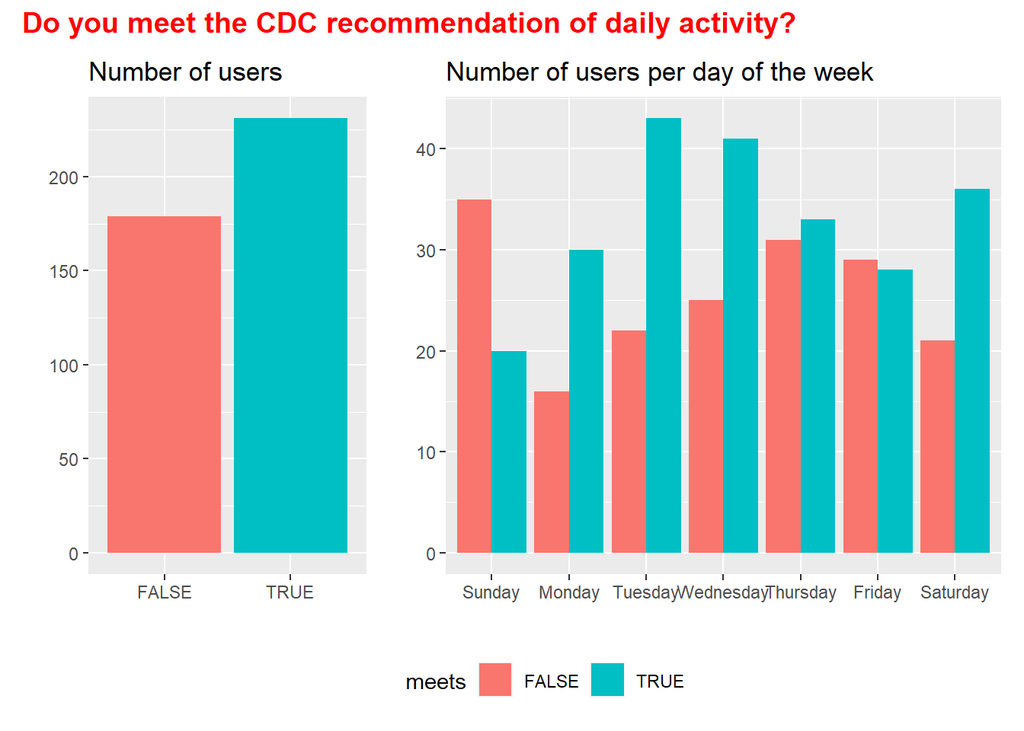

```r
## After removing incomplete weeks, most users seem to reach the appropriate levels of active minutes. Let's see on a daily basis

daily_meet_count <- days %>%
  group_by(id, activity_date) %>%
  mutate(active_min = sum(fairly_active_minutes, very_active_minutes),
         meets = active_min > (150/7)) %>%
  ggplot() + geom_bar(mapping = aes(x=meets,fill=meets)) +
  labs(title = "Number of users", x = "", y = "")

daily_meet <- days %>%
  group_by(id, activity_date) %>%
  mutate(active_min = sum(fairly_active_minutes, very_active_minutes),
         meets = active_min > (150/7)) %>%
  ggplot() + geom_bar(mapping = aes(x=day_of_week,fill=meets), position = "dodge") +
  labs(title = "Number of users per day of the week",
       x = "", y = "")

daily_meet_count + daily_meet +
  plot_layout(widths = c(1,2), guides = 'collect') +
  plot_annotation(title = "Do you meet the CDC recommendation of daily activity?",
                  theme = theme(title = element_text(colour = "red",face = "bold", size = 12))) &
  theme(legend.position = "bottom")
```

## Act

Bellabeat is a high-tech manufacturer of health-focused products for women that has the potential to become a larger player in the global smart device market.

We present the following insights from our analysis of FitBit Fitness Tracker Data, as well as recommendations for Bellabeat’s marketing strategy in hopes of achieving this goal, while also keeping in mind **our mission:**

> Bellabeat empowers women to reconnect with themselves, unleash their inner strengths and be what they were meant to be

#### 1. What are some trends in smart device usage?

We have made some observations about the trends in smart device usage using the data, the most noteworthy of which are:

- Relatively low-level intensities of activity have a very strong relationship with calorie burning
- Most distance was covered by light intensity levels
- Users come from a wide variety of activity levels
- Trends in activity:
  - users were most typically active at 6:00pm, followed by 12:00pm (most steps, highest intensity)
  - however, users could have also hit their max intensity anytime between 5:00am and 8:00p
  - activity tended to increase at 5:00am and decrease at 8:00pm
- Calories burned had the strongest relationship with very active minutes and total distance
- On average, users only sleep the recommended 8 hours on Sundays

#### 2. How could these trends apply to Bellabeat customers?

The FitBit seems to most closely resemble the Leaf tracker as Bellabeat’s classic smart device. As they measure very similar things, we chose to compare it to that product. As the functionality is very similar, we believe the trends we see are applicable to Leaf tracker users.

#### 3. How could these trends help influence Bellabeat marketing strategy?

**Our recommendations for the app:**

- **informing** users that moderately intense activity assists in
  - lowering risk of getting sick (including from COVID-19)
  - helping prevent obesity
  - other tremendous health benefits
- informing users that *brisk walking* counts as moderate activity (CDC), especially toward those who don’t typically engage in higher intensities of activity, and that even light walking has strong calorie-burning benefits
- giving users an in-app opportunity to customize and individualize **benchmarks** for
  - reaching intensity goals (e.g., hitting weekly moderate/very active minutes)
  - step or distance goals (e.g., 10,000 steps per day)
  - hours in bed (e.g., going to bed at a consistent time)
  - general goals (e.g., losing weight, staying in shape)
- if a user’s goal is to lose weight, informing them that either spending more time in very active and intense exercise or traveling a greater distance each day (regardless of intensity) can help burn more calories
- rewarding those who hit goals through some kind of **point system or game to increase engagement** (e.g., notifications that say “You’ve walked this far today–keep going!”)
- **personalized notifications** for:
  - times when users are typically active
  - reaching individual goals
  - taking more steps
  - engaging in more intense activity
  - time for bed
- encouraging setting a **rest day** for recomposition

**Our recommendations for targeting new users:**

- advertising **individualized notifications** (e.g., our devices can take into account your work schedule and send reminders)
- promoting **customizable features** (e.g., goal setting)
- focusing on the great health benefits of even just light activity, and rewarding those who are just starting to engage in more light activity

**Our suggested marketing strategy can be encapsulated by the following quote from the CDC:**

> Adults should move more and sit less throughout the day. Some physical activity is better than none. Adults who sit less and do any amount of moderate-to-vigorous intensity physical activity gain some health benefits.

– [CDC “How much physical activity do adults need?”](https://www.cdc.gov/physicalactivity/basics/adults/index.htm)

#### Additional data to use in the future

As stated in Prepare section, this data was very limited. The most glaring issue was the lack of demographics. In the future, it is important to include this information to have more confidence that the findings of the analysis are representative of Bellabeat users. This would also expand the analysis to see trends in certain groups, e.g., differences in usage across BMI.

[figure not shown]

#### Thank you

Thank you for reading my Bellabeats case study from the Google Data Analytics certificate! As this is my first project using R, please let me know if you have any recommendations.

Special thanks and credit to [Macarena Lacasa’s notebook](https://www.kaggle.com/code/macarenalacasa/capstone-case-study-bellabeat/notebook) from which I drew much inspiration.